# Predictive Power of Volatility for Momentum Profits on the JSE

Mwangele Kaluba

10 September 2019

## Introduction

In this document, I show the code I used to perform the tests for my research. Refer to my Research Objective for a description of the methodology that I follow here.

### **1. Setting up my workspace**

In this section, I load prerequisite settings for my R session.

#### **1.1 Clearing previously saved workspace**

```r
rm(list = ls())
```

The code above clears the workspace. This is done as using the previously saved workspace defeats the purpose of using a script.

#### **1.2 Installing and loading packages**

```r
# install.packages('tidyquant')
# install.packages('tbl2xts')
library(tidyquant)
library(tbl2xts)
```

The tidyquant package contains all of the packages I use for all the code run here, with the exception of the tbl2xts package. The tbl2xts package is a useful package that integrates xts objects with the tidyverse. The primary use of tbl2xts will be to convert tibbles to xts objects. This is necessary because dplr verbs return tibbles.

The tidyquant package contains a combination of the tidyverse packages as well as frequently used financial and quantitative packages. One of the packages installed from the quantitative finance world is quantmod, which installs xts, zoo, TTR and PerformanceAnalytics.

#### **1.3 Setting up global options**

```r
options("scipen"=99)
```

Here I penalise scientific notation.

#### **1.4 Calling custom functions**

```r
source("ggplot.PerformanceSummary.R")
```

### **2. Importing Data**

```r
file_path <- paste0(getwd(), "/")
price_file <- paste0(file_path, "Prices.csv")
volume_file <- paste0(file_path, "Volume.csv")
mcap_file <- paste0(file_path, "Mcap.csv")
```

```r
na_strings <- c("", "NA", "#N/A", "#N/A N/A", "nl", "#N/A Invalid Security")

col_arg <- cols(.default = "d", Dates = "c")

prices <- read_csv(price_file, col_types = col_arg, na = na_strings, guess_max = Inf)
mcaps <- read_csv(mcap_file, col_types = col_arg, na = na_strings, guess_max = Inf)
volume <- read_csv(volume_file, col_types = col_arg, na = na_strings, guess_max = Inf)
```

### **3. Cleaning Data**

#### **3.1 Removing Duplicated Columns**

```r
prices <- prices %>%
  select(-contains("_"))

mcaps <- mcaps %>%
  select(-contains("_"))

volume <- volume %>%
  select(-contains("_"))
```

The read_csv() function from readr differs from the base read.csv() in the way they treat duplicated columns.

#### **3.2 Deleting Columns with no Data**

```r
prices <- prices %>% select_if(~!all(is.na(.)))
```

```r
mcaps <- mcaps %>%
  select(colnames(prices))

volume <- volume %>%
  select(colnames(prices))
```

### **4. Data Transformations**

#### **4.1 Creating xts objects**

```r
prices <- prices %>%
  mutate(date = ymd(Dates)) %>%
  select(date, everything()) %>%
  select(-Dates) %>%
  tbl_xts()

mcaps <- mcaps %>%
  mutate(date = ymd(Dates)) %>%
  select(date, everything()) %>%
  select(-Dates) %>%
  tbl_xts()

volume <- volume %>%
  mutate(date = ymd(Dates)) %>%
  select(date, everything()) %>%
  select(-Dates) %>%
  tbl_xts()
```

#### **4.2 Price Filter**

```r
pr <- prices
pr[prices < 1] <- NA
prices <- pr
remove(pr)
```

#### **4.3. Calculating Returns**

```r
ret <- Return.calculate(prices, method = "discrete")
ret <- ret[-1,]
ret <- ret["2000/2018"]
calc_rets <- ret
```

#### **4.4 Prior 12-month return**

```r
yearly <- seq(from = 2000, to = 2018, by = 1)
ret_prior <- ret
ret_prior[!is.na(ret)] <- 1

for(i in yearly){
  ext <- paste(i)
  prior <- colSums(is.na(ret_prior[ext,,]))
  prior <- prior[prior > 0]
  ret_prior[ext,names(prior)] <- NA
  }

ret <- ret * ret_prior
```

#### **4.5 Liquidity filter**

```r
liq_fil <- ret
liq_fil[ret != 0] <- 1

for(i in yearly){
  ext <- paste(i)
  ZDT <- colSums(ret[ext,,]==0, na.rm = T)
  ZDT <- ZDT[ZDT > 100]
  liq_fil[ext,names(ZDT)] <- NA
  }

ret <- ret * liq_fil

ann <- prices[endpoints(ret, 'years'),,]
```

#### **4.6 Market Cap Filter**

```r
mcap100 <- t(apply(-mcaps["2000/2018"], 1, rank))
mcap100[mcap100 > 100] <- NA
mcap_mask <- mcap100
mcap_mask[!is.na(mcap_mask)] <- 1
ret <- ret * mcap_mask[-1,]

mcap_mask <- xts(mcap_mask, order.by = index(mcaps["2000/2018"]))
```

### **5. Momentum**

#### **5.1 Momentum Sorts**

```r
ret_months <- apply.monthly(ret, Return.cumulative)
skip <- 12

mom <- rollapply(ret_months, skip, function(x) 1 + Return.cumulative(x[-skip]))
```

```r
monthly_cap <- mcap_mask[index(ret_months)]
mom <- mom * monthly_cap
rank.twelve <- t(apply(-mom, 1, rank, ties.method = "first"))
```

```r
rank.twelve[rank.twelve > 100] <- NA

mom_win <- mom_p2 <- mom_p3 <- mom_p4 <- mom_lose <- rank.twelve
mom_win[mom_win > 20] <- NA
mom_p2[mom_p2 > 20 & mom_p2 <= 40] <- NA
mom_p3[mom_p3 > 40 & mom_p3 <= 60] <- NA
mom_p4[mom_p4 > 60 & mom_p4 <= 80] <- NA
mom_lose[mom_lose > 80] <- NA
```

```r
mom_port <- setNames(lapply(ls(pattern="mom_"), function(x) get(x)), ls(pattern="mom_"))
CGR <- matrix(NA, nrow = 217, ncol = 1)
port.rets <- vector("list", length = length(mom_port))

for(i in 1:length(mom_port)){
  temp <- mom_port[[i]]
  temp <- temp[-c(1:11),,drop=F]
  for(r in 1:nrow(temp)){
    df <- temp[r,,drop=F] %>% as.data.frame() %>% select_if(~!all(is.na(.)))
    ext <- rownames(df) %>% ymd() + 5
    ext <- ext %>% as.character() %>% substr(., 1, 7)
    p <- calc_rets[ext, colnames(df)]
    pr <- Return.cumulative(p)
    CGR[r,1] <- sum(pr) / ncol(pr)
  }
  port.rets[[i]] <- CGR
}
```

```r
Winner <- port.rets[[5]]
Loser <- port.rets[[1]]
port <- cbind(Winner,Loser)
port <- xts(port, order.by = index(ret_months[-c(1:11),]))
port <- port[-nrow(port),]
colnames(port) <- c("Winner", "Loser")
```

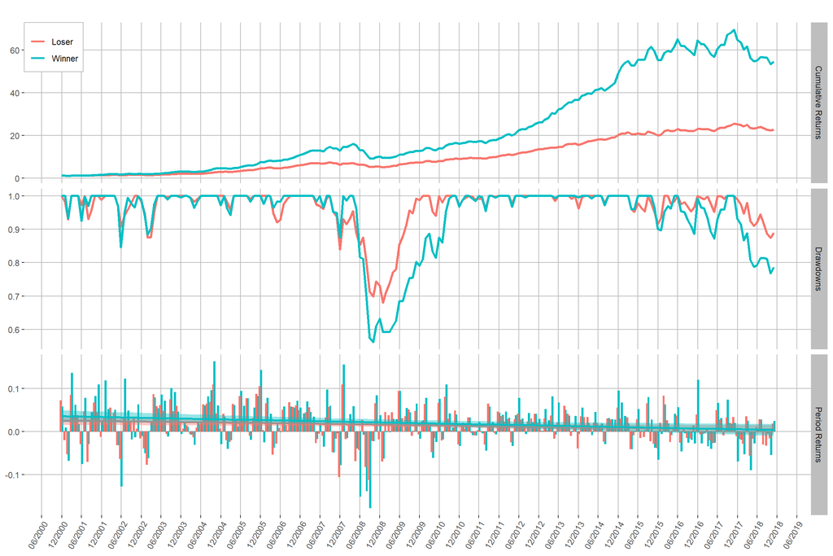

```r
gg.PerformanceSummary(port)
```

```r
WML <- Winner - Loser
colnames(WML) <- "Momentum Payoff"
WML <- xts(WML,  order.by = index(ret_months[-c(1:11),]))
WML <- WML[-nrow(WML),]
```

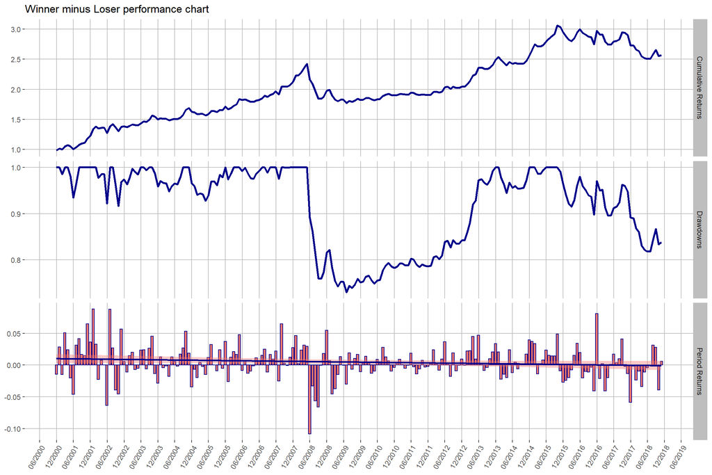

```r
gg.PerformanceSummary(WML, ptitle = "Winner minus Loser performance chart")
```